# Notebook

### Web Information Retrieval and Data Mining - Assignment 3

```
Student: Van Gendt, Fabien (0918181)
```

#### Answer 1.1, Baseline (4p)

- Dense network, at least 3 layers, shaped like a pyramid
  - Last layer: 10 nodes, sigmoid.
  - Loss: categorical cross-entropy. Metric: accuracy
- No preprocessing, regularization. Get at least 70% accuracy.
- Explain design decisions. Discuss performance.
  - Does it overfit (large/growing gap between loss and val_loss)?

[output not shown]

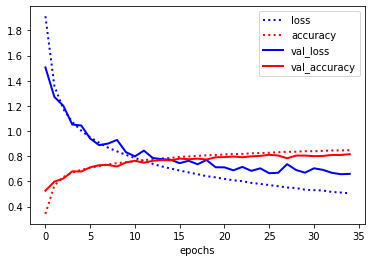

```
Model: "sequential_88"
_________________________________________________________________
Layer (type)                 Output Shape              Param #
=================================================================
flatten_86 (Flatten)         (None, 3072)              0
_________________________________________________________________
dense_420 (Dense)            (None, 300)               921900
_________________________________________________________________
dense_421 (Dense)            (None, 200)               60200
_________________________________________________________________
dense_422 (Dense)            (None, 100)               20100
_________________________________________________________________
dense_423 (Dense)            (None, 10)                1010
=================================================================
Total params: 1,003,210
Trainable params: 1,003,210
Non-trainable params: 0
_________________________________________________________________
None
def build_model_1_1():
    model = models.Sequential()
    model.add(layers.Flatten(input_shape=(32,32,3)))
    model.add(layers.Dense(300, activation='relu'))
    model.add(layers.Dense(200, activation='relu'))
    model.add(layers.Dense(100, activation='relu'))

    model.add(layers.Dense(10, activation='softmax'))

    opt = optimizers.RMSprop(learning_rate=0.0001)

    model.compile(optimizer=opt, loss='categorical_crossentropy', metrics=['accuracy'])
    return model
```

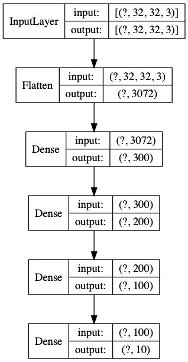

#### Answer 1.2, Preprocess (2p)

- Convert images to greyscale, other preprocessing optional.
  - Input shape should be (32,32,1)
- Explain design decisions. Is it better? Why (not)?
  - Color information is likely not so useful for classification. Greyscale makes the network smaller, less parameters to learn, less likely to overfit.

[output not shown]

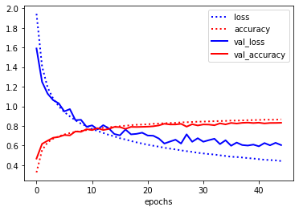

```
Model: "sequential_137"
_________________________________________________________________
Layer (type)                 Output Shape              Param #
=================================================================
flatten_135 (Flatten)        (None, 1024)              0
_________________________________________________________________
dense_604 (Dense)            (None, 300)               307500
_________________________________________________________________
dense_605 (Dense)            (None, 200)               60200
_________________________________________________________________
dense_606 (Dense)            (None, 100)               20100
_________________________________________________________________
dense_607 (Dense)            (None, 10)                1010
=================================================================
Total params: 388,810
Trainable params: 388,810
Non-trainable params: 0
_________________________________________________________________
None
def build_model_1_2():
    model = models.Sequential()
    model.add(layers.Flatten(input_shape=(32,32,1)))
    model.add(layers.Dense(300, activation='relu'))
    model.add(layers.Dense(200, activation='relu'))
    model.add(layers.Dense(100, activation='relu'))
    model.add(layers.Dense(10, activation='softmax'))

    opt = optimizers.RMSprop(learning_rate=0.0001)

    model.compile(optimizer=opt, loss='categorical_crossentropy', metrics=['accuracy'])
    return model
```

#### Answer 1.3, Tune (4p)

- Regularize the model. What works best?
  - Should consider batch normalization, dropout, l1/l2 regularization (or Nesterov)
- Tune other hyperparameters (e.g. learning rate, batch size,...) as you see fit.
  - At least consider tuning learning rate, ideally also momentum, decay, other optimizers
- Explain your findings and final design decisions. Discuss the results.
  - Should be better, at least it shouldn't overfit

[output not shown]

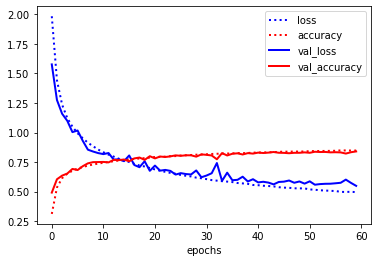

```
def build_model_1_3():
    model = models.Sequential()
    model.add(layers.Flatten(input_shape=(32,32,1)))
    model.add(layers.Dense(300, activation='relu'))#, kernel_regularizer=regularizers.l1(0.00001)))
    model.add(layers.Dropout(0.1))
    model.add(layers.Dense(200, activation='relu'))#, kernel_regularizer=regularizers.l1(0.00001)))
    model.add(layers.Dropout(0.05))
    model.add(layers.Dense(100, activation='relu'))#, kernel_regularizer=regularizers.l1(0.00001)))
    model.add(layers.Dropout(0.01))
#     model.add(layers.Dense(300, activation='relu'))
#     model.add(layers.Dense(200, activation='relu'))
#     model.add(layers.Dense(100, activation='relu'))
    model.add(layers.Dense(10, activation='softmax'))

    opt = optimizers.RMSprop(learning_rate=0.0001)

    model.compile(optimizer=opt, loss='categorical_crossentropy', metrics=['accuracy'])
    return model
```

#### Answer 2.1, ConvNet (7p)

- Build a sequential ConvNet, get at least 90% accuracy.
  - Conv2D layers, input shape (32,32,1)
  - Consider using blocks of Conv2D layers with maxpooling in between
  - Use zero-padding in Conv2D layers because the images are small
  - At least one dense hidden layer and dense output layer (sigmoid)
  - Consider adding batch normalization, dropout
  - Consider small dropout rates in beginning, larger dropout rates later in network
  - Consider other optimizers and tuning learning rate, momentum,...
- Explain what you did and why (800 chars). Is it working well?
  - Should be quite elaborate and sensible

[output not shown]

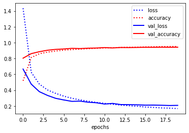

```
Model: "sequential_79"
_________________________________________________________________
Layer (type)                 Output Shape              Param #
=================================================================
conv2d_305 (Conv2D)          (None, 32, 32, 32)        320
_________________________________________________________________
conv2d_306 (Conv2D)          (None, 32, 32, 32)        9248
_________________________________________________________________
max_pooling2d_196 (MaxPoolin (None, 16, 16, 32)        0
_________________________________________________________________
dropout_141 (Dropout)        (None, 16, 16, 32)        0
_________________________________________________________________
conv2d_307 (Conv2D)          (None, 16, 16, 64)        18496
_________________________________________________________________
conv2d_308 (Conv2D)          (None, 16, 16, 64)        36928
_________________________________________________________________
max_pooling2d_197 (MaxPoolin (None, 8, 8, 64)          0
_________________________________________________________________
dropout_142 (Dropout)        (None, 8, 8, 64)          0
_________________________________________________________________
conv2d_309 (Conv2D)          (None, 8, 8, 128)         73856
_________________________________________________________________
max_pooling2d_198 (MaxPoolin (None, 4, 4, 128)         0
_________________________________________________________________
dropout_143 (Dropout)        (None, 4, 4, 128)         0
_________________________________________________________________
flatten_71 (Flatten)         (None, 2048)              0
_________________________________________________________________
dense_156 (Dense)            (None, 128)               262272
_________________________________________________________________
dense_157 (Dense)            (None, 10)                1290
=================================================================
Total params: 402,410
Trainable params: 402,410
Non-trainable params: 0
_________________________________________________________________
None
def build_model_2_1():
    model = models.Sequential()
    model.add(layers.Conv2D(32, (3, 3), activation='relu', input_shape=(32,32,1), padding='same'))
    model.add(layers.Conv2D(32, (3, 3), activation='relu', padding='same'))
    model.add(layers.MaxPooling2D((2,2)))
    model.add(layers.Dropout(0.1))
    model.add(layers.Conv2D(64, (3, 3), activation='relu', padding='same'))
    model.add(layers.Conv2D(64, (3, 3), activation='relu', padding='same'))
    model.add(layers.MaxPooling2D((2,2)))
    model.add(layers.Dropout(0.2))
    model.add(layers.Conv2D(128, (3, 3), activation='relu', padding='same'))
    model.add(layers.MaxPooling2D((2, 2)))
    model.add(layers.Dropout(0.3))
    model.add(layers.Flatten())
    model.add(layers.Dense(128, activation='relu'))
    model.add(layers.Dense(10, activation='softmax'))

    opt = optimizers.RMSprop(0.0003)

    model.compile(loss='categorical_crossentropy', optimizer=opt, metrics=['accuracy'])
    return model
```

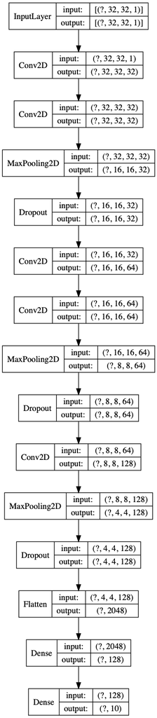

#### Answer 2.2, Data Augmentation (3p)

- Augment the preprocessed training data.
  - Use small variations (small shifts up-down, left-right) of flips becasue the images are small
  - Large shifts and rotations distort the image too much
- Explain what you did and why. Discuss the performance of the model.

[output not shown]

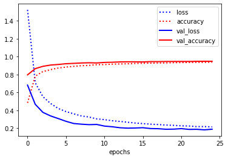

```
img_gen = ImageDataGenerator(
      rotation_range=0.1,
      width_shift_range=0.05,
      height_shift_range=0.05,
      zoom_range=0.15,
      fill_mode='nearest')
```

#### Answer 3.1, Misclassifications (2p)

[output not shown]

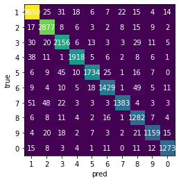

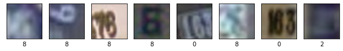

#### Answer 3.2, Activations (4p)

- Retrieve and visualize the activations for one example
- For every filter for different convolutional layers (at different depths in the network).
- Give an explanation. Is your model indeed learning something useful?
  - Should detect edges etc in first layers, higher-order object (e.g. interesting regions) in deeper layers.

[output not shown]

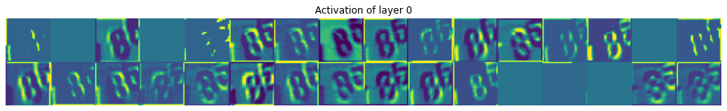

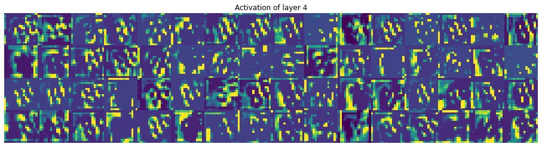

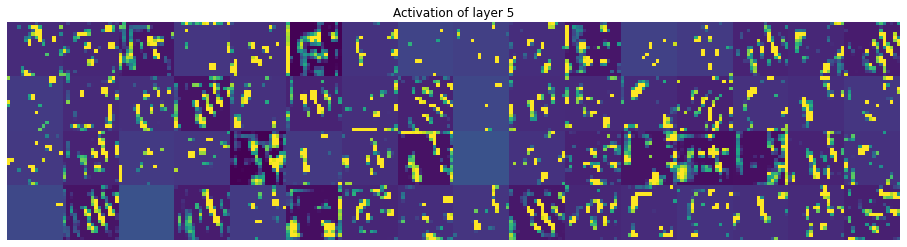

#### Answer 3.3, Class activation map (4p)

- Show a class activation map for your last convolutional layer
- Superimpose the activation map over the image, or plot side by side
  - Should make sense, detect interesting regions to classify the number

```
def plot_activation_map(image, label_idx):
    #Eager execution needed to be turned off in order to retrieve the gradients.
    tf.compat.v1.disable_eager_execution()

    img = image
    batch_img = np.expand_dims(img, axis=0)
    model = load_model_from_file(base_dir, "model_2_2")
    last_conv_layer = model.get_layer("conv2d_99")

    gradients = K.gradients(model.output[:,label_idx], last_conv_layer.output)[0]
    pooled_gradients = K.mean(gradients, axis=(0,1,2))
    iterate = K.function([model.input], [pooled_gradients, last_conv_layer.output[0]])
    pooled_gradients_value, conv_layer_output_value = iterate([batch_img])
    for i in range(128):
        conv_layer_output_value[:, :, i] *= pooled_gradients_value[i]

    heatmap = np.mean(conv_layer_output_value, axis=-1)
    heatmap = np.maximum(heatmap, 0)
    heatmap /= np.max(heatmap)
    heatmap = cv2.resize(heatmap, (img.shape[1], img.shape[0]))
    heatmap = np.uint8(255 * heatmap)
    heatmap = cv2.applyColorMap(heatmap, cv2.COLORMAP_JET)
    heatmap_inversed = cv2.cvtColor(heatmap.astype('float32'), cv2.COLOR_BGR2RGB)
    superimposed_img = (0.3*heatmap_inversed)+(255 * img)
    plt.title("Class activation map, label index {}".format(label_idx))
    plt.axis('off')
    plt.imshow(superimposed_img.astype('uint8'))
```

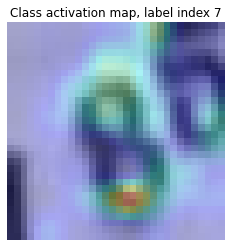

#### Answer 4.1, Fast feature extraction (5p)

- Import the VGG16 model, pretrained on ImageNet
- Freeze convolutional base, adds a dense layer
- Consider unfreezing the last few convolutional layers and evaluate whether that works better
  - Check if they do. It is very likely to help.
- Discuss the observed performance
  - Should get around 80% accuracy

[output not shown]

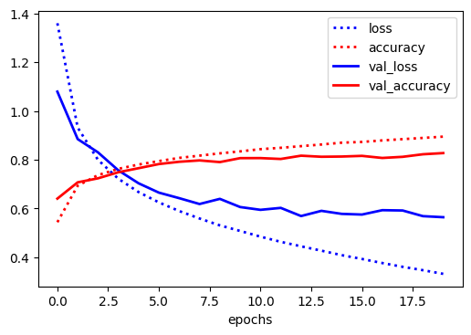

```
Model: "sequential_15"
_________________________________________________________________
Layer (type)                 Output Shape              Param #
=================================================================
block1_conv1 (Conv2D)        (None, 32, 32, 64)        1792
_________________________________________________________________
block1_conv2 (Conv2D)        (None, 32, 32, 64)        36928
_________________________________________________________________
block1_pool (MaxPooling2D)   (None, 16, 16, 64)        0
_________________________________________________________________
block2_conv1 (Conv2D)        (None, 16, 16, 128)       73856
_________________________________________________________________
block2_conv2 (Conv2D)        (None, 16, 16, 128)       147584
_________________________________________________________________
block2_pool (MaxPooling2D)   (None, 8, 8, 128)         0
_________________________________________________________________
block3_conv1 (Conv2D)        (None, 8, 8, 256)         295168
_________________________________________________________________
block3_conv2 (Conv2D)        (None, 8, 8, 256)         590080
_________________________________________________________________
block3_conv3 (Conv2D)        (None, 8, 8, 256)         590080
_________________________________________________________________
block3_pool (MaxPooling2D)   (None, 4, 4, 256)         0
_________________________________________________________________
block4_conv1 (Conv2D)        (None, 4, 4, 512)         1180160
_________________________________________________________________
block4_conv2 (Conv2D)        (None, 4, 4, 512)         2359808
_________________________________________________________________
block4_conv3 (Conv2D)        (None, 4, 4, 512)         2359808
_________________________________________________________________
block4_pool (MaxPooling2D)   (None, 2, 2, 512)         0
_________________________________________________________________
block5_conv1 (Conv2D)        (None, 2, 2, 512)         2359808
_________________________________________________________________
block5_conv2 (Conv2D)        (None, 2, 2, 512)         2359808
_________________________________________________________________
block5_conv3 (Conv2D)        (None, 2, 2, 512)         2359808
_________________________________________________________________
block5_pool (MaxPooling2D)   (None, 1, 1, 512)         0
_________________________________________________________________
```

[output cut: 12 more lines]

[output not shown]

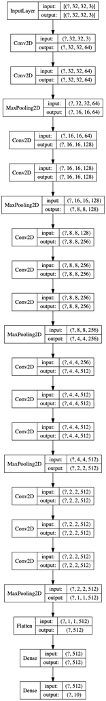

#### Answer 4.2, Embeddings (5p)

- Generate embeddings with the trained convolutional part of model_4_1 (without the dense layer)
- Embed the training and test data and store them to disk
- Build and evaluate a pipeline on the embedded data
  - Check if pipeline makes sense (e.g. use models that can handle many dimensions)
- Describe what you did and what you observed (max 800 chars).
  - Consider different models, preprocessing, tuning, etc.
  - Check performance (see original Submission.html) when in doubt. We did not run all the evaluations because it takes too long, and the output is ill-defined.

[output not shown]

```
Running time: 12.22 seconds
Last modified: May 26, 2020
scikit-learn version: 0.23.1
```